# Annual Report

## Middle Earth Annual Report

This annual report documents wildlife monitoring activities in Middle Earth from 2023-01-01 to 2023-12-31. The figures and tables were generated from the `dbGetSummaryData()`, `dbPlotSummary()`, and `dbTableSummary()` functions from the R package, *AMMonitor.* The report was generated from a Quarto script.

## Field Visits

Autonomous monitoring units were deployed at 3 in Middle Earth, where devices captured wildlife on trail cameras and audio recorders (Figure 1).

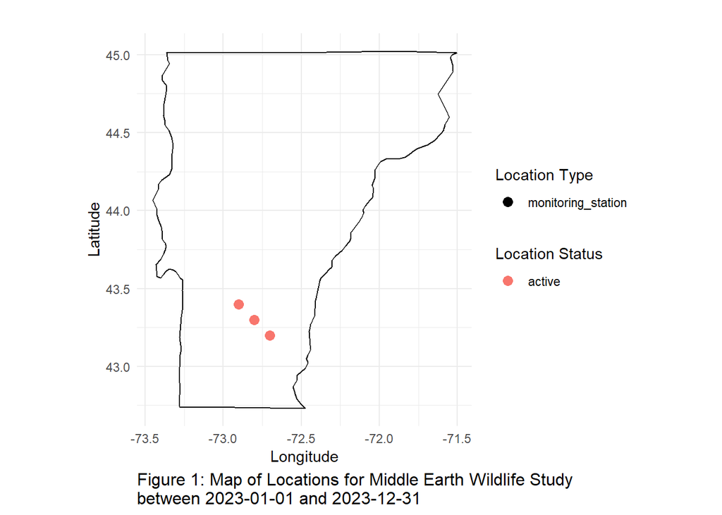

Field technicians made a total of 4 visits to monitoring stations to collect media files (Table 1).

Table 1.

Visits Associated with Collected Media

by Year and Location

| Year | Location ID | Total Visits |
| --- | --- | --- |
| 2023 | locationA | 2 |
| 2023 | locationB | 1 |
| 2023 | locationC | 1 |

## Media Files

At the monitoring locations, a total of 26 files were captured in the report time period (Table 2).

Table 2

Collected Media Files

by Year and Media Type

| Year | Media Type | Count |
| --- | --- | --- |
| 2023 | audio | 1 |
| 2023 | photo | 25 |

## Annotations

Media files (camera images and audio files) were labeled by both hobbits and machine learning models. Hobbit labeling was done with the *AMMonitor* shiny interface, in which a hobbit manually inspected media files and identified monitoring targets within. Annotations per tagger for all taxa are shown in Figure 2.

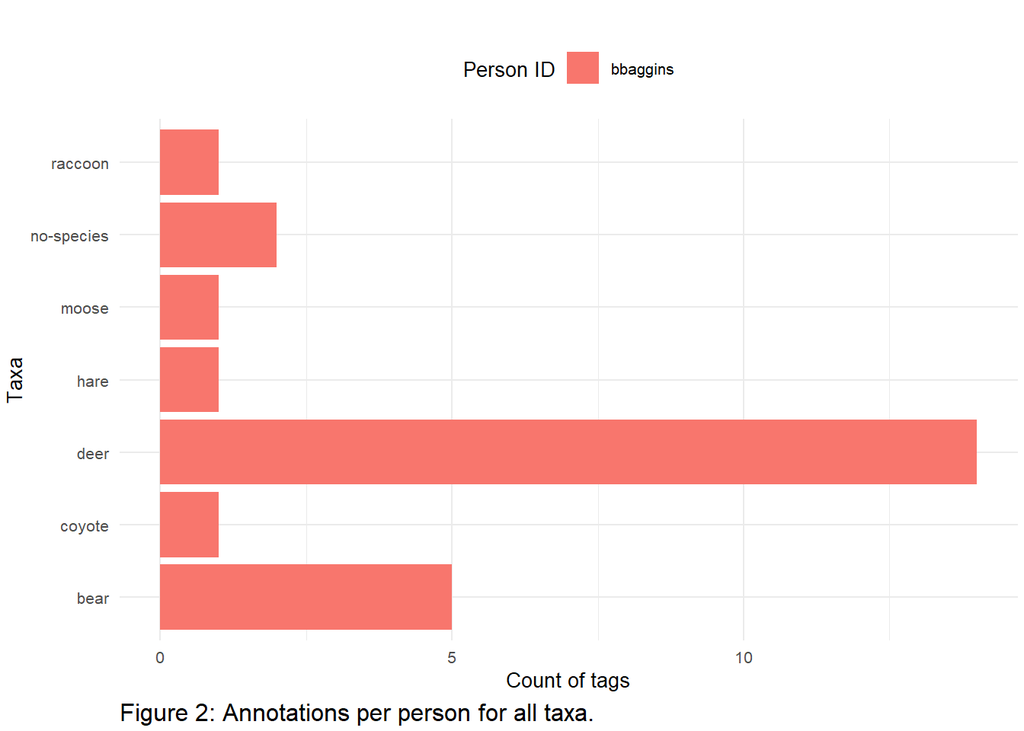

## Machine Learning Detections

Table 3.

Model Outputs by Year

| Model | Year | animal sp. | btnw | eato | etti | gcfl | oven |
| --- | --- | --- | --- | --- | --- | --- | --- |
| BirdNET24 | 2023 | 0 | 3 | 1 | 1 | 1 | 7 |
| MegaDetector | 2023 | 33 | 0 | 0 | 0 | 0 | 0 |
| btnw_bt | 2023 | 0 | 4 | 0 | 0 | 0 | 0 |
| btnw_ct | 2023 | 0 | 3 | 0 | 0 | 0 | 0 |
| oven_ct | 2023 | 0 | 0 | 0 | 0 | 0 | 3 |

## Summary

In summary, it was a great year for the Middle Earth wildlife monitoring program. Our focus for the next year will be building species distribution models from the hobbit- and machine-tagged data.

Respectfully submitted,

```
Gandolf
```